# Churn Prediction - Kickoff

Tony Kuo

June 23, 2016

## Request

- We want every customer to have a score that indicates how likely he or she is to churn during the next 6-12 months
- Inputs to this score should include both purchase history and engagement history, and maybe other factors
- The score should be constantly updated so that marketing channel owners can use the information as an input to campaign and feature design
- Random forest analysis is recommended

## Models to be Adopted

- Binary classification
  - Logistic regression
  - **Random forest(recommended)**
- Survival analysis

## Predictors to be Discussed

- Purchase history data, including order pattern, order recency, categories purchased, cancellations, coupon usage, Coupang Cash usage, and use of Coupang exclusive services
- Engagement data, including visit pattern, visit recency, visit channels (e.g. paid, organic, app push, email), visit platforms, application version, and opt-in to CRM programs
- Acquisition data, including purchase history information tied to their first purchase (above), date of first purchase, date of install, acquisition channel (e.g. Organic, Paid Display Ads, Paid Search, etc.), and acquisition publisher (e.g. Cauly Display Ads, Naver Search)
- Demographic data, including age, gender, zip code, and zip-code based roll ups (e.g. rural vs. urban)

## Data Sources to be Discussed

- PDA tables
- Hive tables
- SCI(Customer Science Interface)
- …etc.

## TODO

- Align business jargons
  - e.g. How to define an **active** customer(still with us)
  - How to translate those jargons to queries
- Preparing a document for Analysis Base Table
  - Data sources validation
  - Mapping rule for each predictor

## A Quick Glimpse on Survival

- time: number of days between the day of their last purchased and today

```r
demo <- read.csv('/Users/tkuo/Downloads/survival.csv')
head(demo)
```

```
##   female start time churned
## 1      0    92  273       0
## 2      0     5  360       0
## 3      0   357    8       0
## 4      0   154  211       0
## 5      0   118  247       0
## 6      1   308   57       0
```

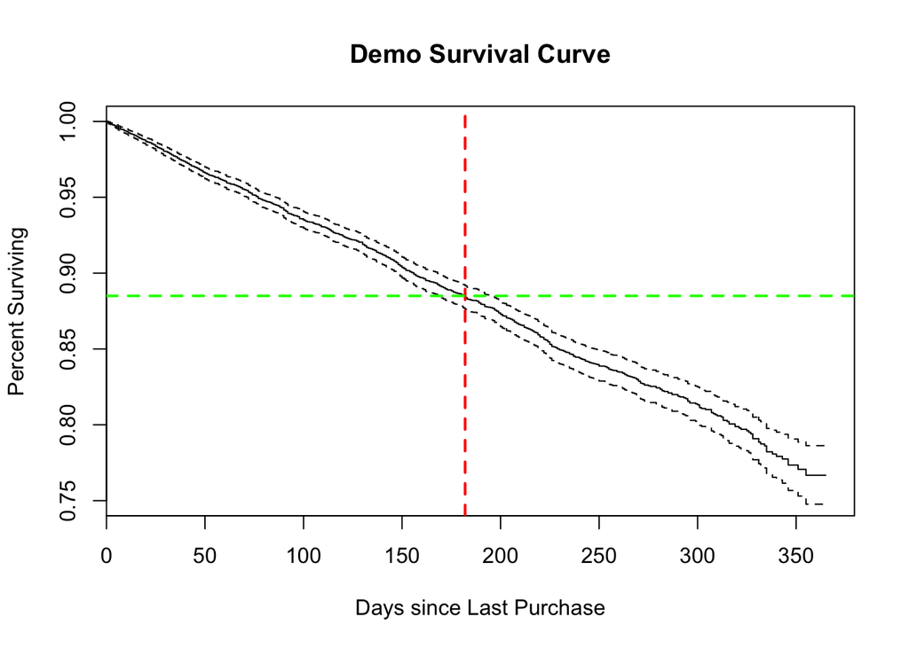

```r
# Use the survival library
library(survival)
# Create a "survival object" for each observation, using time and churn data.
demo$survival <- Surv(demo$time, demo$churned == 1)
# Fit a basic survival curve using the data
fit <- survfit(survival ~ 1, data = demo)
# Plot the survival curve and add a title!
plot(fit, lty = 1, mark.time = FALSE, ylim=c(.75,1), xlab = 'Days since Last Purchase', ylab = 'Percent Surviving')
title(main = 'Demo Survival Curve')
abline(v = 182, lty = 2, col = "red", lwd = 2)
abline(h = 0.885, lty = 2, col = "green", lwd = 2)
```

We can expect 11% of customers will be churned given our definition of **182 days** without a single purchase.

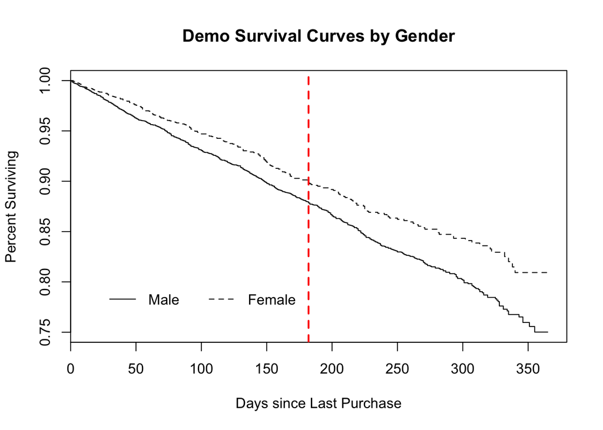

```r
# Fit survival curves based on the female binary
fit <- survfit(survival ~ female, data = demo)
# Plot the results, add a legend, add a title
plot(fit, lty = 1:2, mark.time = FALSE, ylim=c(.75,1), xlab = 'Days since Last Purchase', ylab = 'Percent Surviving')
legend(20, .8, c('Male', 'Female'), lty=1:2, bty = 'n', ncol = 2)
title(main = "Demo Survival Curves by Gender")
abline(v = 182, lty = 2, col = "red", lwd = 2)
```

```r
# And run a log-rank test
survdiff(survival ~ female, data = demo)
```

```
## Call:
## survdiff(formula = survival ~ female, data = demo)
##
##             N Observed Expected (O-E)^2/E (O-E)^2/V
## female=0 6722      830      778      3.48      12.4
## female=1 2532      251      303      8.94      12.4
##
##  Chisq= 12.4  on 1 degrees of freedom, p= 0.000422
```

- Women are sticking with us much longer than their male counterparts
- Maybe we should do a survey to see why men don’t like our business as much